# Case Stduy Bellabeat_Report

Aseem Mehrotra

03/09/2021

## **Google Data Analytics Capstone Project**

## **Bellabeat Case Study: How Can a Wellness Technology Company Play it Smart**

**Bellabeat is a high-tech manufacturer of health-focused products for women. As per the co-founder & CCO of Bellabeat (Urska Srsen), analyzing device fitness data could help unlock new growth opportunities for the company. Contributing to the vision of CCO, this report focuses on the data collected for FitBit Fitness Tracker data to gain insight into how customers are using there smart devices.**

In this document following steps of Data Analysis Process are followed:

- Ask
- Prepare
- Process
- Analyze
- Share
- Act

### Phase 1: Ask

#### Key Objectives:

##### 1. The Business Task:

- 1. **Analyse the Fitbit usage data** in order to gain insight into how consumers use non-Bellabeat smart devices
- 2. Use these insights to **inform Bellabeat Marketing Strategy** for the product **“Time”** by Bellabeat.

#### 2. Elaborate Business Task:

Given the dataset, the business task is to search for user patterns of usage of their smart devices in order to gain insights that would better orientate marketing decisions. In short, in this report I will try to answer the question **"How do people use the smart devices?**

#### 3. Key Stake Holders:

The main stakeholders are:

- Co-founder & Chief Creative Officer: Bellabeat
- Co-founder & Mathematician: Bellabeat
- Marketing Analytics Team: Bellabeat

### Phase 2: Prepare

#### 1. Data Source:

- The data used in this case study is from the **Kaggle Notebook by the user Mobius**
- According to metadata, the original data comes from **Zenodo**

#### 2. Shortcomings of the Given Data

- Data is old: Data was collected 5 years ago (in 2016)
- Data is small: The sample size of data is 33 FitBit users
- Data may be non-inclusive: The identities of the FitBit users are anonymous, so the data may not be inclusive of all ages, genders, economic backgrounds, geography and ethnicities.

#### 3. Data Cleaning

- The data cleaned using R through RStudio
- Data cleaning code with outcome is as follows

### Loading Packages

```r
library(tidyverse)
library(readxl)
library(reshape2)
library(scales)
library(sqldf)
library(janitor)
library(lubridate)
```

### Reading Unique Data from the Dataset

```r
# The code will read unique observations in each dataset. Thus removing the duplicates (if any)
dailyAct <- unique(read.csv("dailyActivity_merged.csv"))
dailyCal <- unique(read.csv("dailyCalories_merged.csv"))
dailyInt <- unique(read.csv("dailyIntensities_merged.csv"))
dailyStep <- unique(read.csv("dailySteps_merged.csv"))
heartRate <- unique(read.csv("heartrate_seconds_merged.csv"))
slpDay <- unique(read.csv("sleepDay_merged.csv"))
wtInfo <- unique(read.csv("weightLogInfo_merged.csv"))
```

### Identifying NULL Values

```r
# Null Values in each Column of Data Frame
lapply(dailyAct, function(x) { length(which(is.na(x)))})
```

```
## $Id
## [1] 0
##
## $ActivityDate
## [1] 0
##
## $TotalSteps
## [1] 0
##
## $TotalDistance
## [1] 0
##
## $TrackerDistance
## [1] 0
##
## $LoggedActivitiesDistance
## [1] 0
##
## $VeryActiveDistance
## [1] 0
##
## $ModeratelyActiveDistance
## [1] 0
##
## $LightActiveDistance
## [1] 0
##
## $SedentaryActiveDistance
## [1] 0
##
## $VeryActiveMinutes
## [1] 0
##
## $FairlyActiveMinutes
## [1] 0
##
## $LightlyActiveMinutes
## [1] 0
##
## $SedentaryMinutes
## [1] 0
##
## $Calories
## [1] 0
```

```r
lapply(dailyCal, function(x) { length(which(is.na(x)))})
```

```
## $Id
## [1] 0
##
## $ActivityDay
## [1] 0
##
## $Calories
## [1] 0
```

```r
lapply(dailyInt, function(x) { length(which(is.na(x)))})
```

```
## $Id
## [1] 0
##
## $ActivityDay
## [1] 0
##
## $SedentaryMinutes
## [1] 0
##
## $LightlyActiveMinutes
## [1] 0
##
## $FairlyActiveMinutes
## [1] 0
##
## $VeryActiveMinutes
## [1] 0
##
## $SedentaryActiveDistance
## [1] 0
##
## $LightActiveDistance
## [1] 0
##
## $ModeratelyActiveDistance
## [1] 0
##
## $VeryActiveDistance
## [1] 0
```

```r
lapply(dailyStep, function(x) { length(which(is.na(x)))})
```

```
## $Id
## [1] 0
##
## $ActivityDay
## [1] 0
##
## $StepTotal
## [1] 0
```

```r
lapply(heartRate, function(x) { length(which(is.na(x)))})
```

```
## $Id
## [1] 0
##
## $Time
## [1] 0
##
## $Value
## [1] 0
```

```r
lapply(slpDay, function(x) { length(which(is.na(x)))})
```

```
## $Id
## [1] 0
##
## $SleepDay
## [1] 0
##
## $TotalSleepRecords
## [1] 0
##
## $TotalMinutesAsleep
## [1] 0
##
## $TotalTimeInBed
## [1] 0
```

```r
lapply(wtInfo, function(x) { length(which(is.na(x)))})
```

```
## $Id
## [1] 0
##
## $Date
## [1] 0
##
## $WeightKg
## [1] 0
##
## $WeightPounds
## [1] 0
##
## $Fat
## [1] 65
##
## $BMI
## [1] 0
##
## $IsManualReport
## [1] 0
##
## $LogId
## [1] 0
```

```r
# Weight Log Info database wtInfo has 65 missing or NULL values in "Fat" column.
```

**The above code ensures that no duplicates exist in the imported data-sets and null values are also identified in individual data-sets.**

### Summary of Daily Data-sets

```r
colnames(dailyAct)
```

```
##  [1] "Id"                       "ActivityDate"
##  [3] "TotalSteps"               "TotalDistance"
##  [5] "TrackerDistance"          "LoggedActivitiesDistance"
##  [7] "VeryActiveDistance"       "ModeratelyActiveDistance"
##  [9] "LightActiveDistance"      "SedentaryActiveDistance"
## [11] "VeryActiveMinutes"        "FairlyActiveMinutes"
## [13] "LightlyActiveMinutes"     "SedentaryMinutes"
## [15] "Calories"
```

```r
head(dailyAct)
```

```
##           Id ActivityDate TotalSteps TotalDistance TrackerDistance
## 1 1503960366    4/12/2016      13162          8.50            8.50
## 2 1503960366    4/13/2016      10735          6.97            6.97
## 3 1503960366    4/14/2016      10460          6.74            6.74
## 4 1503960366    4/15/2016       9762          6.28            6.28
## 5 1503960366    4/16/2016      12669          8.16            8.16
## 6 1503960366    4/17/2016       9705          6.48            6.48
##   LoggedActivitiesDistance VeryActiveDistance ModeratelyActiveDistance
## 1                        0               1.88                     0.55
## 2                        0               1.57                     0.69
## 3                        0               2.44                     0.40
## 4                        0               2.14                     1.26
## 5                        0               2.71                     0.41
## 6                        0               3.19                     0.78
##   LightActiveDistance SedentaryActiveDistance VeryActiveMinutes
## 1                6.06                       0                25
## 2                4.71                       0                21
## 3                3.91                       0                30
## 4                2.83                       0                29
## 5                5.04                       0                36
## 6                2.51                       0                38
##   FairlyActiveMinutes LightlyActiveMinutes SedentaryMinutes Calories
## 1                  13                  328              728     1985
## 2                  19                  217              776     1797
## 3                  11                  181             1218     1776
## 4                  34                  209              726     1745
## 5                  10                  221              773     1863
## 6                  20                  164              539     1728
```

```r
colnames(dailyCal)
```

```
## [1] "Id"          "ActivityDay" "Calories"
```

```r
head(dailyCal)
```

```
##           Id ActivityDay Calories
## 1 1503960366   4/12/2016     1985
## 2 1503960366   4/13/2016     1797
## 3 1503960366   4/14/2016     1776
## 4 1503960366   4/15/2016     1745
## 5 1503960366   4/16/2016     1863
## 6 1503960366   4/17/2016     1728
```

```r
colnames(dailyInt)
```

```
##  [1] "Id"                       "ActivityDay"
##  [3] "SedentaryMinutes"         "LightlyActiveMinutes"
##  [5] "FairlyActiveMinutes"      "VeryActiveMinutes"
##  [7] "SedentaryActiveDistance"  "LightActiveDistance"
##  [9] "ModeratelyActiveDistance" "VeryActiveDistance"
```

```r
head(dailyInt)
```

```
##           Id ActivityDay SedentaryMinutes LightlyActiveMinutes
## 1 1503960366   4/12/2016              728                  328
## 2 1503960366   4/13/2016              776                  217
## 3 1503960366   4/14/2016             1218                  181
## 4 1503960366   4/15/2016              726                  209
## 5 1503960366   4/16/2016              773                  221
## 6 1503960366   4/17/2016              539                  164
##   FairlyActiveMinutes VeryActiveMinutes SedentaryActiveDistance
## 1                  13                25                       0
## 2                  19                21                       0
## 3                  11                30                       0
## 4                  34                29                       0
## 5                  10                36                       0
## 6                  20                38                       0
##   LightActiveDistance ModeratelyActiveDistance VeryActiveDistance
## 1                6.06                     0.55               1.88
## 2                4.71                     0.69               1.57
## 3                3.91                     0.40               2.44
## 4                2.83                     1.26               2.14
## 5                5.04                     0.41               2.71
## 6                2.51                     0.78               3.19
```

```r
colnames(dailyStep)
```

```
## [1] "Id"          "ActivityDay" "StepTotal"
```

```r
head(dailyStep)
```

```
##           Id ActivityDay StepTotal
## 1 1503960366   4/12/2016     13162
## 2 1503960366   4/13/2016     10735
## 3 1503960366   4/14/2016     10460
## 4 1503960366   4/15/2016      9762
## 5 1503960366   4/16/2016     12669
## 6 1503960366   4/17/2016      9705
```

**Column names of Daily Calories and Daily Intensities data-sets already exist in Daily Activity Data-set**

### Summary of other Data-sets (used in this study)

```r
colnames(heartRate)
```

```
## [1] "Id"    "Time"  "Value"
```

```r
head(heartRate)
```

```
##           Id                 Time Value
## 1 2022484408 4/12/2016 7:21:00 AM    97
## 2 2022484408 4/12/2016 7:21:05 AM   102
## 3 2022484408 4/12/2016 7:21:10 AM   105
## 4 2022484408 4/12/2016 7:21:20 AM   103
## 5 2022484408 4/12/2016 7:21:25 AM   101
## 6 2022484408 4/12/2016 7:22:05 AM    95
```

```r
colnames(wtInfo)
```

```
## [1] "Id"             "Date"           "WeightKg"       "WeightPounds"
## [5] "Fat"            "BMI"            "IsManualReport" "LogId"
```

```r
head(wtInfo)
```

```
##           Id                  Date WeightKg WeightPounds Fat   BMI
## 1 1503960366  5/2/2016 11:59:59 PM     52.6     115.9631  22 22.65
## 2 1503960366  5/3/2016 11:59:59 PM     52.6     115.9631  NA 22.65
## 3 1927972279  4/13/2016 1:08:52 AM    133.5     294.3171  NA 47.54
## 4 2873212765 4/21/2016 11:59:59 PM     56.7     125.0021  NA 21.45
## 5 2873212765 5/12/2016 11:59:59 PM     57.3     126.3249  NA 21.69
## 6 4319703577 4/17/2016 11:59:59 PM     72.4     159.6147  25 27.45
##   IsManualReport        LogId
## 1           True 1.462234e+12
## 2           True 1.462320e+12
## 3          False 1.460510e+12
## 4           True 1.461283e+12
## 5           True 1.463098e+12
## 6           True 1.460938e+12
```

### Phase 3: Process

#### 1. Compare different data-sets

- Different data-sets are compared using sqldf() & nrow() functions to identify the number of rows in different data sets

```r
# Compare Daily Activity and Daily Calories data-sets for number of rows
dailyActCal <- dailyAct %>%
  select(Id, ActivityDate, Calories)
check1a <- nrow(sqldf("SELECT * FROM dailyActCal INTERSECT SELECT * FROM dailyCal"))
check1b <- nrow(dailyAct)
check1c <- nrow(dailyCal)
check1a
```

```
## [1] 940
```

```r
check1b
```

```
## [1] 940
```

```r
check1c
```

```
## [1] 940
```

**Daily Activity, Daily Calorie & new data-set of INTERSECTION of these 2 contain the similar number of rows: 940.**

```r
dailyActInt <- dailyAct %>%
  select(Id, ActivityDate, SedentaryMinutes, LightlyActiveMinutes, FairlyActiveMinutes, VeryActiveMinutes, SedentaryActiveDistance, LightActiveDistance, ModeratelyActiveDistance, VeryActiveDistance)
check2a <- nrow(sqldf("SELECT * FROM dailyActInt INTERSECT SELECT * FROM dailyInt"))
check2b <- nrow(dailyAct)
check2c <- nrow(dailyInt)
check2a
```

```
## [1] 940
```

```r
check2b
```

```
## [1] 940
```

```r
check2c
```

```
## [1] 940
```

**Daily Activity, Daily Intensities & new data-set of INTERSECTION of these 2 contain the similar number of rows: 940.**

**Daily Activity data-set can be used out of these 3 data-sets for analysis as Daily Activity data-set already has the observations which are present in Daily Calories & Daily Intensities Data-sets**

#### 2. Join Data-Sets

**Left Join Daily Activity Data-Set with Heart Rate, Sleep & weight Data-Sets**

```r
dailyHR <- sqldf("SELECT Id, Value AS HeartRate, TRIM(SUBSTR(Time,1,9)) AS Date FROM heartRate")
dailyActHR <- sqldf("SELECT A.*, B.HeartRate FROM dailyAct AS A LEFT JOIN dailyHR AS B ON A.Id = B.Id AND A.ActivityDate = B.Date")

dailySlp <- sqldf("SELECT Id, TRIM(SUBSTR(SleepDay,1,9)) AS Date, TotalSleepRecords, TotalMinutesAsleep, TotalTimeInBed FROM slpDay")
dailyActHRSlp <- sqldf("SELECT A.*, B.TotalSleepRecords, B.TotalMinutesAsleep, B.TotalTimeInBed FROM dailyActHR AS A LEFT JOIN dailySlp AS B ON A.Id = B.Id AND A.ActivityDate = B.Date")

wtLog <- sqldf("SELECT Id, TRIM(SUBSTR(Date,1,9)) AS Date, WeightKg, BMI FROM wtInfo")
dailyActHRSlpWt <- sqldf("SELECT A.*, B.WeightKg, B.BMI FROM dailyActHRSlp AS A LEFT JOIN wtLog AS B ON A.Id = B.Id AND A.ActivityDate = B.date")
```

**The data-set named “dailyActHRSlpWt” will be used for further analysis in this report.**

#### 3. Clean Data Names in the Data-set

```r
dailyActHRSlpWt <- dailyActHRSlpWt %>%
  clean_names()
```

#### 4. Data Types Change

```r
# Change Activity Date Column to Date Data Type
dailyActHRSlpWt <- dailyActHRSlpWt %>%
  mutate(activity_date = mdy(activity_date))

# Change ID column from Numeric to Character for ease in the analysis
dailyActHRSlpWt <- dailyActHRSlpWt %>%
  mutate(id = as.character(id))
```

#### 5. Summary of the Data

```r
names(dailyActHRSlpWt)
```

```
##  [1] "id"                         "activity_date"
##  [3] "total_steps"                "total_distance"
##  [5] "tracker_distance"           "logged_activities_distance"
##  [7] "very_active_distance"       "moderately_active_distance"
##  [9] "light_active_distance"      "sedentary_active_distance"
## [11] "very_active_minutes"        "fairly_active_minutes"
## [13] "lightly_active_minutes"     "sedentary_minutes"
## [15] "calories"                   "heart_rate"
## [17] "total_sleep_records"        "total_minutes_asleep"
## [19] "total_time_in_bed"          "weight_kg"
## [21] "bmi"
```

```r
head(dailyActHRSlpWt)
```

```
##           id activity_date total_steps total_distance tracker_distance
## 1 1503960366    2016-04-12       13162           8.50             8.50
## 2 1503960366    2016-04-13       10735           6.97             6.97
## 3 1503960366    2016-04-14       10460           6.74             6.74
## 4 1503960366    2016-04-15        9762           6.28             6.28
## 5 1503960366    2016-04-16       12669           8.16             8.16
## 6 1503960366    2016-04-17        9705           6.48             6.48
##   logged_activities_distance very_active_distance moderately_active_distance
## 1                          0                 1.88                       0.55
## 2                          0                 1.57                       0.69
## 3                          0                 2.44                       0.40
## 4                          0                 2.14                       1.26
## 5                          0                 2.71                       0.41
## 6                          0                 3.19                       0.78
##   light_active_distance sedentary_active_distance very_active_minutes
```

[output cut: 27 more lines]

```r
summarise(dailyActHRSlpWt)
```

```
## data frame with 0 columns and 1 row
```

```r
glimpse(dailyActHRSlpWt)
```

```
## Rows: 2,484,264
## Columns: 21
## $ id                         <chr> "1503960366", "1503960366", "1503960366", "…
## $ activity_date              <date> 2016-04-12, 2016-04-13, 2016-04-14, 2016-0…
## $ total_steps                <int> 13162, 10735, 10460, 9762, 12669, 9705, 130…
## $ total_distance             <dbl> 8.50, 6.97, 6.74, 6.28, 8.16, 6.48, 8.59, 9…
## $ tracker_distance           <dbl> 8.50, 6.97, 6.74, 6.28, 8.16, 6.48, 8.59, 9…
## $ logged_activities_distance <dbl> 0, 0, 0, 0, 0, 0, 0, 0, 0, 0, 0, 0, 0, 0, 0…
## $ very_active_distance       <dbl> 1.88, 1.57, 2.44, 2.14, 2.71, 3.19, 3.25, 3…
## $ moderately_active_distance <dbl> 0.55, 0.69, 0.40, 1.26, 0.41, 0.78, 0.64, 1…
## $ light_active_distance      <dbl> 6.06, 4.71, 3.91, 2.83, 5.04, 2.51, 4.71, 5…
## $ sedentary_active_distance  <dbl> 0, 0, 0, 0, 0, 0, 0, 0, 0, 0, 0, 0, 0, 0, 0…
## $ very_active_minutes        <int> 25, 21, 30, 29, 36, 38, 42, 50, 28, 19, 66,…
## $ fairly_active_minutes      <int> 13, 19, 11, 34, 10, 20, 16, 31, 12, 8, 27, …
## $ lightly_active_minutes     <int> 328, 217, 181, 209, 221, 164, 233, 264, 205…
## $ sedentary_minutes          <int> 728, 776, 1218, 726, 773, 539, 1149, 775, 8…
## $ calories                   <int> 1985, 1797, 1776, 1745, 1863, 1728, 1921, 2…
## $ heart_rate                 <int> NA, NA, NA, NA, NA, NA, NA, NA, NA, NA, NA,…
## $ total_sleep_records        <int> 1, 2, NA, 1, 2, 1, NA, 1, 1, 1, NA, 1, 1, 1…
## $ total_minutes_asleep       <int> 327, 384, NA, 412, 340, 700, NA, 304, 360, …
## $ total_time_in_bed          <int> 346, 407, NA, 442, 367, 712, NA, 320, 377, …
## $ weight_kg                  <dbl> NA, NA, NA, NA, NA, NA, NA, NA, NA, NA, NA,…
## $ bmi                        <dbl> NA, NA, NA, NA, NA, NA, NA, NA, NA, NA, NA,…
```

```r
summary(dailyActHRSlpWt)
```

```
##       id            activity_date         total_steps    total_distance
##  Length:2484264     Min.   :2016-04-12   Min.   :    0   Min.   : 0.000
##  Class :character   1st Qu.:2016-04-19   1st Qu.: 6083   1st Qu.: 4.200
##  Mode  :character   Median :2016-04-26   Median :10140   Median : 7.100
##                     Mean   :2016-04-26   Mean   : 9891   Mean   : 7.177
##                     3rd Qu.:2016-05-04   3rd Qu.:12346   3rd Qu.: 8.740
##                     Max.   :2016-05-12   Max.   :36019   Max.   :28.030
##
##  tracker_distance logged_activities_distance very_active_distance
##  Min.   : 0.000   Min.   :0.0000             Min.   : 0.00
##  1st Qu.: 4.200   1st Qu.:0.0000             1st Qu.: 0.00
##  Median : 7.100   Median :0.0000             Median : 0.98
##  Mean   : 7.142   Mean   :0.1674             Mean   : 2.05
##  3rd Qu.: 8.680   3rd Qu.:0.0000             3rd Qu.: 3.00
##  Max.   :28.030   Max.   :4.9421             Max.   :21.92
##
##  moderately_active_distance light_active_distance sedentary_active_distance
##  Min.   :0.0000             Min.   : 0.000        Min.   :0.000000
##  1st Qu.:0.0000             1st Qu.: 3.150        1st Qu.:0.000000
##  Median :0.4400             Median : 4.330        Median :0.000000
##  Mean   :0.6759             Mean   : 4.395        Mean   :0.003235
##  3rd Qu.:1.0400             3rd Qu.: 5.580        3rd Qu.:0.000000
##  Max.   :6.4800             Max.   :10.710        Max.   :0.110000
##
##  very_active_minutes fairly_active_minutes lightly_active_minutes
##  Min.   :  0.00      Min.   :  0.00        Min.   :  0.0
##  1st Qu.:  0.00      1st Qu.:  0.00        1st Qu.:195.0
##  Median : 17.00      Median : 14.00        Median :238.0
##  Mean   : 32.79      Mean   : 17.61        Mean   :243.6
##  3rd Qu.: 50.00      3rd Qu.: 29.00        3rd Qu.:294.0
##  Max.   :210.00      Max.   :143.00        Max.   :518.0
##
##  sedentary_minutes    calories      heart_rate     total_sleep_records
##  Min.   :   0.0    Min.   :   0   Min.   : 36.00   Min.   :1.0
##  1st Qu.: 662.0    1st Qu.:2086   1st Qu.: 63.00   1st Qu.:1.0
##  Median : 775.0    Median :2629   Median : 73.00   Median :1.0
##  Mean   : 841.1    Mean   :2686   Mean   : 77.33   Mean   :1.1
##  3rd Qu.:1065.0    3rd Qu.:3089   3rd Qu.: 88.00   3rd Qu.:1.0
##  Max.   :1440.0    Max.   :4900   Max.   :203.00   Max.   :3.0
##                                   NA's   :606      NA's   :854695
##  total_minutes_asleep total_time_in_bed   weight_kg            bmi
##  Min.   : 58.0        Min.   : 61.0     Min.   : 52.6     Min.   :21.5
##  1st Qu.:385.0        1st Qu.:408.0     1st Qu.: 61.4     1st Qu.:24.0
##  Median :436.0        Median :461.0     Median : 62.1     Median :24.2
##  Mean   :425.9        Mean   :455.3     Mean   : 71.5     Mean   :24.9
##  3rd Qu.:478.0        3rd Qu.:526.0     3rd Qu.: 85.1     3rd Qu.:25.6
##  Max.   :796.0        Max.   :961.0     Max.   :133.5     Max.   :47.5
##  NA's   :854695       NA's   :854695    NA's   :2007285   NA's   :2007285
```

### Phase 4: Analysis

#### 1. Calories Burned vs Total Steps Grouped by User Id

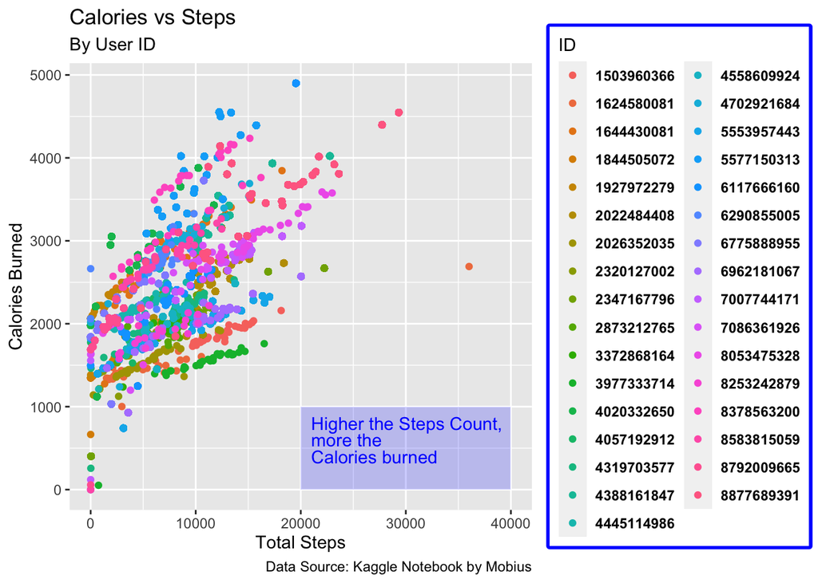

```r
# Calories Burned vs Total Steps by ID: Scatter Plot
dailyActHRSlpWt %>%
  ggplot(mapping = aes(x=total_steps, y=calories))+
  geom_point(mapping = aes(color = id))+
  labs(x="Total Steps", y= "Calories Burned", title = "Calories vs Steps", subtitle = "By User ID", caption = "Data Source: Kaggle Notebook by Mobius", color = "ID")+
  annotate("rect", xmin = 20000, xmax = 40000, ymin = 0, ymax = 1000, alpha = 0.2, fill = "blue")+
  annotate("text", x= 21000, y= 800, label = "Higher the Steps Count,  ", color = "blue", hjust = "left")+
  annotate("text", x= 21000, y= 600, label = "more the ", color = "blue", hjust = "left")+
  annotate("text", x= 21000, y= 400, label = "Calories burned", color = "blue", hjust = "left")+
  theme(legend.box.background = element_rect(color = "Blue", size = 2), legend.text = element_text(face = "bold"))
```

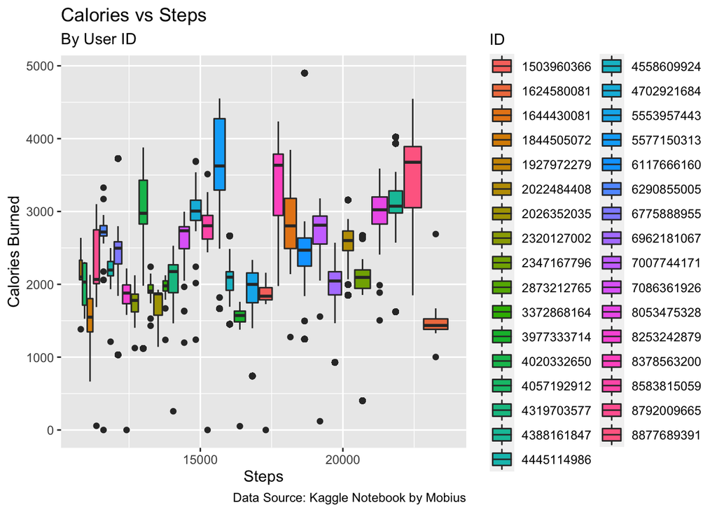

```r
# Calories vs Steps by User ID: Box Plot
dailyActHRSlpWt %>%
  select(id, total_steps, calories) %>%
  group_by(id) %>%
  ggplot(mapping = aes(x = total_steps, y= calories))+
  geom_boxplot(aes(fill=id))+
  labs(x= "Steps", y= "Calories Burned",title = "Calories vs Steps", subtitle = "By User ID", caption = "Data Source: Kaggle Notebook by Mobius", fill = "ID")
```

Analyzing the above plot it is evident that **"Higher the Steps count, more the Calories Burned**

#### 2. Calories Burned by Users

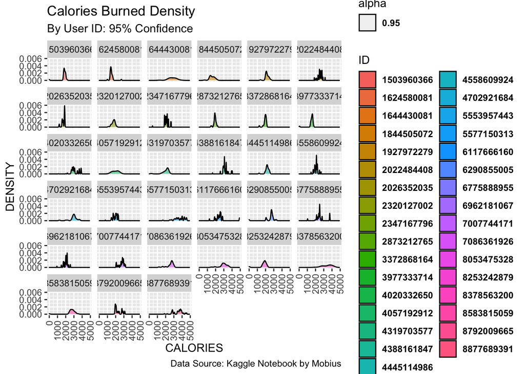

```r
# Calories Burned by User ID: Density Plot
dailyActHRSlpWt %>%
  select(id, total_steps, calories) %>%
  group_by(id) %>%
  ggplot(aes(x= calories))+
  geom_density(aes(fill=factor(id), alpha = 0.95))+
  labs(x="CALORIES", y= "DENSITY", title = "Calories Burned Density", subtitle = "By User ID: 95% Confidence", caption = "Data Source: Kaggle Notebook by Mobius", scientific = FALSE, fill = "ID")+
  theme(legend.box.background = element_rect(color = "Blue", size = 0), legend.text = element_text(face = "bold"), axis.text.x = element_text(angle = 90, vjust = 0.5, hjust =1))+
  facet_wrap(~id)
```

[figure not shown]

```r
# Calories Burned by User ID: Bar Graph
dailyActHRSlpWt %>%
  group_by(id) %>%
  select(id, calories) %>%
  ggplot(mapping = aes(id))+
  geom_bar(mapping = aes(fill = id))+
  labs(x="ID", y= "Calories Burned", title = "Calories vs Steps", subtitle = "By User ID", caption = "Data Source: Kaggle Notebook by Mobius", scientific = FALSE, fill = "ID")+
  theme(legend.box.background = element_rect(color = "Blue", size = 2), legend.text = element_text(face = "bold"), axis.text.x = element_text(angle = 90, vjust = 0.5, hjust =1))
```

#### 3. Steps Taken by Users

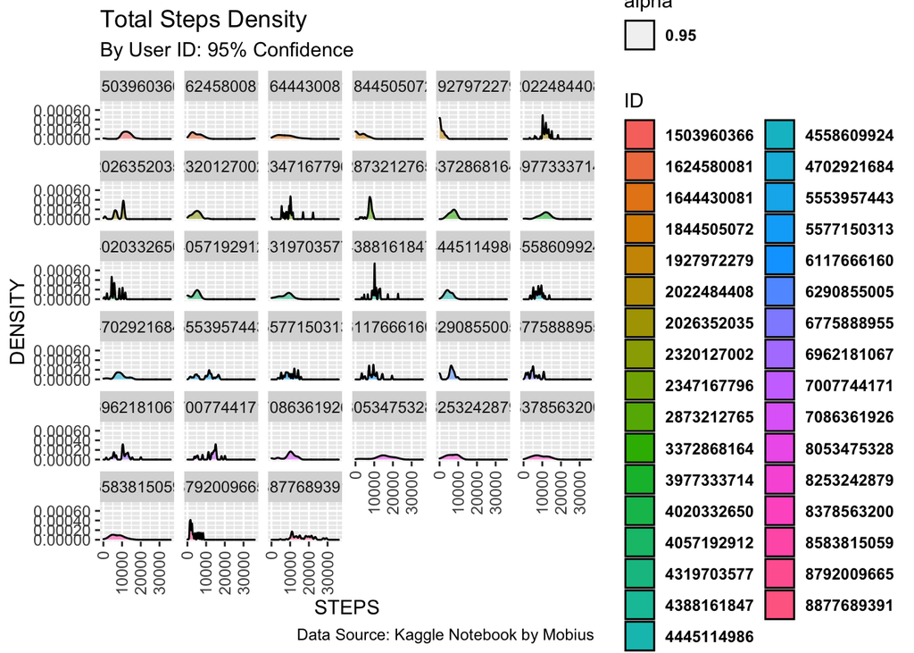

```r
# Total Steps by User ID: Density Plot
dailyActHRSlpWt %>%
  select(id, total_steps, calories) %>%
  ggplot(aes(x= total_steps))+
   scale_y_continuous(labels= scales::comma)+
  geom_density(aes(fill=factor(id), alpha = 0.95))+
  labs(x="STEPS", y= "DENSITY", title = "Total Steps Density", subtitle = "By User ID: 95% Confidence", caption = "Data Source: Kaggle Notebook by Mobius", scientific = FALSE, fill = "ID")+
  theme(legend.box.background = element_rect(color = "Blue", size = 0), legend.text = element_text(face = "bold"), axis.text.x = element_text(angle = 90, vjust = 0.5, hjust =1))+
  facet_wrap(~id)
```

[figure not shown]

```r
# Total Steps by User ID: Bar Graph
# Total Steps by User ID: Bar Graph
dailyActHRSlpWt %>%
  select(id, total_steps) %>%
  ggplot(aes(x= id))+
  scale_y_continuous(labels= scales::comma)+
  geom_bar(aes(fill=factor(id)))+
  labs(x="STEPS", y= "ID", title = "Total Steps", subtitle = "By User ID", caption = "Data Source: Kaggle Notebook by Mobius", scientific = FALSE, fill = "ID")+
  theme(legend.box.background = element_rect(color = "Blue", size = 0), legend.text = element_text(face = "bold"), axis.text.x = element_text(angle = 90, vjust = 0.5, hjust =1))
```

#### 4. Weight Logs

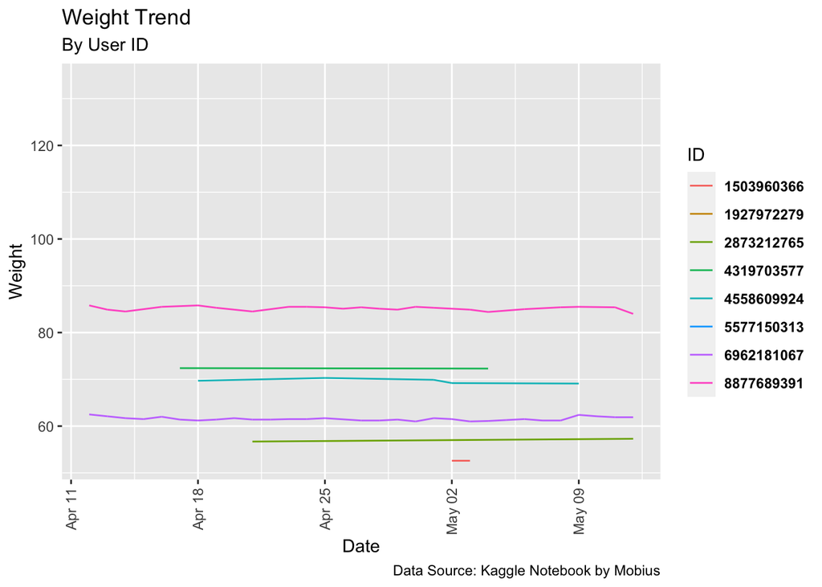

```r
# Weight Trend By User ID
dailyActHRSlpWt %>%
  select(id, activity_date, weight_kg) %>%
  drop_na() %>%
  ggplot(mapping = aes(activity_date, weight_kg))+
  geom_line(aes(color = id))+
  labs(x="Date", y= "Weight", title = "Weight Trend", subtitle = "By User ID", caption = "Data Source: Kaggle Notebook by Mobius", color = "ID")+
  theme(legend.box.background = element_rect(color = "Blue", size = 0), legend.text = element_text(face = "bold"), axis.text.x = element_text(angle = 90, vjust = 0.5, hjust =1))
```

**Weight Log** is not famous among the users and only 8 out of 33 users logged the weight info in the samrt device.

#### 5. Sleep Trends

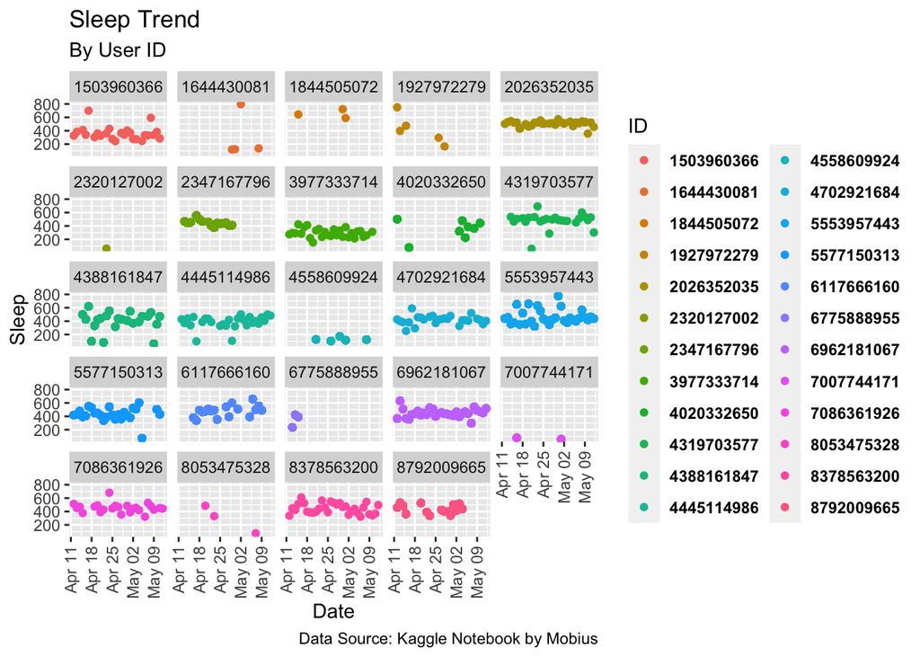

```r
dailyActHRSlpWt %>%
  select(id, activity_date, total_minutes_asleep) %>%
  drop_na() %>%
  ggplot(mapping = aes(activity_date, total_minutes_asleep))+
  geom_point(aes(color = id))+
  labs(x="Date", y= "Sleep", title = "Sleep Trend", subtitle = "By User ID", caption = "Data Source: Kaggle Notebook by Mobius", color = "ID")+
  theme(legend.box.background = element_rect(color = "Blue", size = 0), legend.text = element_text(face = "bold"), axis.text.x = element_text(angle = 90, vjust = 0.5, hjust =1))+
  facet_wrap(~id)
```

**Sleep Tracking is famous feature of smart device among the users. 24 users out of 33 used Fitbit smart device for Sleep tracking.**

#### 6. Heart Rate Trends

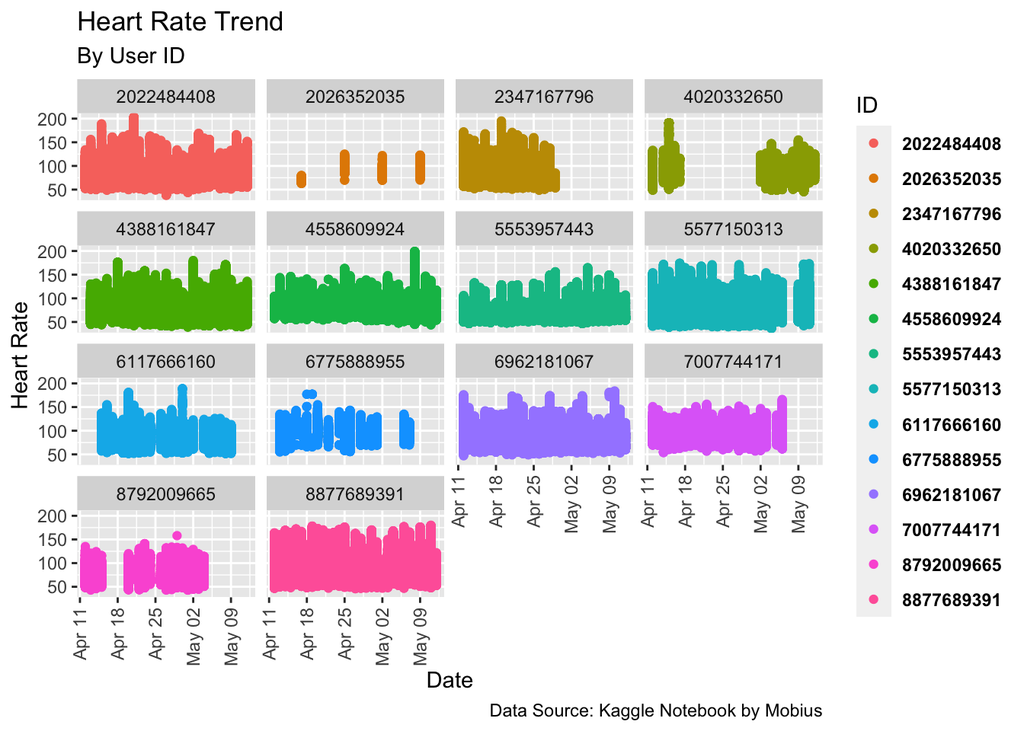

```r
# Heart Rate Trend By User ID
dailyActHRSlpWt %>%
  select(id, activity_date, heart_rate) %>%
  drop_na() %>%
  ggplot(mapping = aes(activity_date, heart_rate))+
  geom_point(aes(color = id))+
  labs(x="Date", y= "Heart Rate", title = "Heart Rate Trend", subtitle = "By User ID", caption = "Data Source: Kaggle Notebook by Mobius", color = "ID")+
  theme(legend.box.background = element_rect(color = "Blue", size = 0), legend.text = element_text(face = "bold"), axis.text.x = element_text(angle = 90, vjust = 0.5, hjust =1))+
  facet_wrap(~id)
```

**Almost 42% FitBit users are utilizing the Heart Rate track feature as per the data available.**

#### 7. Time to Fall Asleep

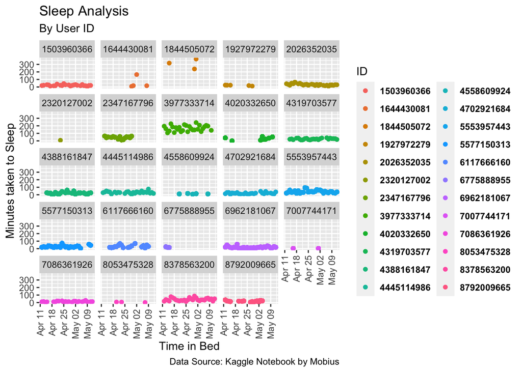

```r
# Time to get sleep
dailyActHRSlpWt %>%
  select(id, activity_date, total_minutes_asleep, total_time_in_bed) %>%
  drop_na() %>%
  ggplot(mapping = aes(activity_date, total_time_in_bed-total_minutes_asleep))+
  geom_point(aes(color = id))+
  labs(x="Time in Bed", y= "Minutes taken to Sleep", title = "Sleep Analysis", subtitle = "By User ID", caption = "Data Source: Kaggle Notebook by Mobius", color = "ID")+
  theme(legend.box.background = element_rect(color = "Blue", size = 0), legend.text = element_text(face = "bold"), axis.text.x = element_text(angle = 90, vjust = 0.5, hjust =1))+
  facet_wrap(~id)
```

### **Use of Fitbit for Calories Burned, Steps Taken, Sleep & Heart Rate tracking is Fairly high as compared to Weight Tracking**

### Phase 5: Share

**This report is available in HTML format on GitHub.**

### Phase 6: Act

## Recommendations based on analysis:

##### 1. Marketing can use the connection between **Steps Taken** & **Calorie Burned** to advertise **Steps Taken** as key for being fit by burning **More Calories**.

##### 2. **Mindfulness Tracking** can be advertised to reduce the stress and can be linked to better sleep.

##### 3. Features like **“Menstrual Tracking”** will enable women to have value addition by using the product from **Bellabeat**